# Total Fitness

Brandie QC

2025-06-16

# Total Fitness at both sites

Total Fitness: p(Establishment)*p(Surv to Rep - y1)*Fruits(y1) + p(Winter Surv)*p(Surv to Rep - y2)*Fruits(y2)

Relating phenology and plasticity to fitness:

- Prob of fitness ~
  - plasticity in size (height, leaf length y1)
  - days to budding
  - plasticity in days to budding
  - Budding duration
- Total fitness ~
  - Days to budding
  - Plasticity in days to budding
  - Budding duration
- Standard error correction on scatter plots

## Libraries

```r
library(tidyverse)
library(magrittr)
#conflicted::conflicts_prefer(dplyr::filter)
library(viridis) #for pretty colors
```

```r
library(ggrepel) #for non-overlapping labels on plots
library(ggdist) #visualizations of distributions and uncertainty
library(ggpubr)
library(cowplot) #plot_grid
#library(sp) #for calculating geographic distance
library(geosphere) #for calculating geographic distance
library(corrplot) #plotting correlations
library(rstatix) #performing cor_test
library(lmerTest) #mixed models
conflicted::conflicts_prefer(lmerTest::lmer)
```

```
## [conflicted] Will prefer lmerTest::lmer over any other package.
```

```r
 library(emmeans) #least squared means
library(broom.mixed)
library(tidymodels)
```

```r
library(furrr) #Apply Mapping Functions in Parallel using Futures
tidymodels_prefer()
# install.packages("multilevelmod")
library(multilevelmod)

library(brms)
#conflicted::conflicts_prefer(brms::ar)
#conflicted::conflicts_prefer(dplyr::combine)
#conflicted::conflicts_prefer(brms::dstudent_t)
library(tidybayes) #for extracting and visiaulizing brms model output
library(modelr) #for data grid

sem <- function(x, na.rm=FALSE) {           #for caclulating standard error
  sd(x,na.rm=na.rm)/sqrt(length(na.omit(x)))
}

#load inv.logit function
inv.logit <- function(f,a) {
  a <- (1-2*a)
  (a*(1+exp(f))+(exp(f)-1))/(2*a*(1+exp(f)))
}

cbbPalette2 <- c("#E69F00","#000000", "#56B4E9","#009E73", "#F0E442", "#0072B2", "#D55E00", "#CC79A7")
timepd_palette <- c("#56B4E9","#D55E00")

options(mc.cores = parallel::detectCores())
```

## Gower’s Distance

```r
garden_climate <- read_csv("../output/Climate/flint_climate_UCDpops.csv") %>%
  filter(parent.pop=="WL2_Garden" | parent.pop=="UCD_Garden") %>%
  select(parent.pop:Long) %>%
  distinct()
garden_climate
```

```
## # A tibble: 2 × 5
##   parent.pop elevation.group elev_m   Lat  Long
##   <chr>      <chr>            <dbl> <dbl> <dbl>
## 1 UCD_Garden Low                 16  38.5 -122.
## 2 WL2_Garden High              2020  38.8 -120.
```

```r
#UCD LAT/LONG = 38.53250, -121.7830
#WL2 Lat/Long = 38.82599, -120.2509

ucd_gowers <- read_csv("../output/Climate/Gowers_UCD.csv") %>%
  select(parent.pop:GrwSsn_GD, Wtr_Year_GD) %>%
  pivot_wider(names_from = TimePd, values_from = c(GrwSsn_GD, Wtr_Year_GD)) %>%
  mutate(UCD_Lat=38.53250, UCD_Long=-121.7830, UCD_Elev=16) %>%
  mutate(Geographic_Dist=distHaversine(cbind(UCD_Long, UCD_Lat), cbind(Long, Lat)),
         Elev_Dist=elev_m-UCD_Elev) %>% # Calculate the distance using the haversine formula (dist in meters)
  #mutate(Lat_Dist=UCD_Lat-Lat, Long_Dist=UCD_Long-Long) %>% #Garden-Home - lat and long per Gerst et al 2011 which kept them separate for some directionality
  rename(pop=parent.pop)
wl2_gowers_2023 <- read_csv("../output/Climate/Gowers_WL2.csv") %>%
  select(parent.pop:GrwSsn_GD, Wtr_Year_GD) %>%
  pivot_wider(names_from = TimePd, values_from = c(GrwSsn_GD, Wtr_Year_GD)) %>%
  mutate(WL2_Lat=38.82599, WL2_Long=-120.2509, WL2_Elev=2020) %>%
  mutate(Geographic_Dist=distHaversine(cbind(WL2_Long, WL2_Lat), cbind(Long, Lat)),
         Elev_Dist=elev_m-WL2_Elev) %>% # Calculate the distance using the haversine formula
  #mutate(Lat_Dist=WL2_Lat-Lat, Long_Dist=WL2_Long-Long) %>% #Garden-Home - lat and long per Gerst et al 2011 which kept them separate for some directionality
  rename(pop=parent.pop)
wl2_gowers_2324 <- read_csv("../output/Climate/Gowers_WL2_2324.csv") %>%
  select(parent.pop:GrwSsn_GD, Wtr_Year_GD) %>%
  pivot_wider(names_from = TimePd, values_from = c(GrwSsn_GD, Wtr_Year_GD)) %>%
  mutate(WL2_Lat=38.82599, WL2_Long=-120.2509, WL2_Elev=2020) %>%
  mutate(Geographic_Dist=distHaversine(cbind(WL2_Long, WL2_Lat), cbind(Long, Lat)),
         Elev_Dist=elev_m-WL2_Elev) %>% # Calculate the distance using the haversine formula
  rename(pop=parent.pop)
```

### Climate Subtraction Distance

```r
ucd_wtr_year_sub_recent <- read_csv("../output/Climate/full_year_Subtraction_Dist_from_Home_Davis_Recent.csv") %>%
  select(parent.pop, Wtr_Year_TempDist_Recent=ann_tmean_dist, Wtr_Year_PPTDist_Recent=ann_ppt_dist)
```

```r
ucd_wtr_year_sub_historic <- read_csv("../output/Climate/full_year_Subtraction_Dist_from_Home_Davis_Historical.csv") %>%
  select(parent.pop, Wtr_Year_TempDist_Historic=ann_tmean_dist, Wtr_Year_PPTDist_Historic=ann_ppt_dist)
ucd_grwssn_sub_recent <- read_csv("../output/Climate/grwssn_Subtraction_Dist_from_Home_Davis_Recent.csv") %>%
  select(parent.pop, GrwSsn_TempDist_Recent=ann_tmean_dist, GrwSsn_PPTDist_Recent=ann_ppt_dist)
ucd_grwssn_sub_historic <- read_csv("../output/Climate/grwssn_Subtraction_Dist_from_Home_Davis_Historical.csv") %>%
  select(parent.pop, GrwSsn_TempDist_Historic=ann_tmean_dist, GrwSsn_PPTDist_Historic=ann_ppt_dist)
ucd_sub_dist <- ucd_wtr_year_sub_recent %>%
  left_join(ucd_wtr_year_sub_historic) %>%
  left_join(ucd_grwssn_sub_recent) %>%
  left_join(ucd_grwssn_sub_historic) %>%
  rename(pop=parent.pop) %>%
  left_join(ucd_gowers)
wl2_wtr_year_sub_recent <- read_csv("../output/Climate/full_year_Subtraction_Dist_from_Home_WL2_Recent.csv") %>%
  select(parent.pop, Wtr_Year_TempDist_Recent=ann_tmean_dist,
         Wtr_Year_PPTDist_Recent=ann_ppt_dist,
         Wtr_Year_CWDDist_Recent=cwd_dist)
wl2_wtr_year_sub_historic <- read_csv("../output/Climate/full_year_Subtraction_Dist_from_Home_WL2_Historical.csv") %>%
  select(parent.pop, Wtr_Year_TempDist_Historic=ann_tmean_dist,
         Wtr_Year_PPTDist_Historic=ann_ppt_dist,
         Wtr_Year_CWDDist_Historic=cwd_dist)
wl2_grwssn_sub_recent <- read_csv("../output/Climate/grwssn_Subtraction_Dist_from_Home_WL2_Recent.csv") %>%
  select(parent.pop, GrwSsn_TempDist_Recent=ann_tmean_dist,
         GrwSsn_PPTDist_Recent=ann_ppt_dist,
         GrwSsn_CWDDist_Recent=cwd_dist)
wl2_grwssn_sub_historic <- read_csv("../output/Climate/grwssn_Subtraction_Dist_from_Home_WL2_Historical.csv") %>%
  select(parent.pop, GrwSsn_TempDist_Historic=ann_tmean_dist,
         GrwSsn_PPTDist_Historic=ann_ppt_dist,
         GrwSsn_CWDDist_Historic=cwd_dist)
wl2_sub_dist_2023 <- wl2_wtr_year_sub_recent %>%
  left_join(wl2_wtr_year_sub_historic) %>%
  left_join(wl2_grwssn_sub_recent) %>%
  left_join(wl2_grwssn_sub_historic) %>%
  rename(pop=parent.pop) %>%
  left_join(wl2_gowers_2023)
wl2_wtr_year_sub_recent_2324 <- read_csv("../output/Climate/full_year_Subtraction_Dist_from_Home_WL2_2324_Recent.csv") %>%
  select(parent.pop, Wtr_Year_TempDist_Recent=ann_tmean_dist,
         Wtr_Year_PPTDist_Recent=ann_ppt_dist,
         Wtr_Year_CWDDist_Recent=cwd_dist)
wl2_wtr_year_sub_historic_2324 <- read_csv("../output/Climate/full_year_Subtraction_Dist_from_Home_WL2_2324_Historical.csv") %>%
  select(parent.pop, Wtr_Year_TempDist_Historic=ann_tmean_dist,
         Wtr_Year_PPTDist_Historic=ann_ppt_dist,
         Wtr_Year_CWDDist_Historic=cwd_dist)
wl2_grwssn_sub_recent_2324 <- read_csv("../output/Climate/grwssn_Subtraction_Dist_from_Home_WL2_2324_Recent.csv") %>%
  select(parent.pop, GrwSsn_TempDist_Recent=ann_tmean_dist,
         GrwSsn_PPTDist_Recent=ann_ppt_dist,
         GrwSsn_CWDDist_Recent=cwd_dist)
wl2_grwssn_sub_historic_2324 <- read_csv("../output/Climate/grwssn_Subtraction_Dist_from_Home_WL2_2324_Historical.csv") %>%
  select(parent.pop, GrwSsn_TempDist_Historic=ann_tmean_dist,
         GrwSsn_PPTDist_Historic=ann_ppt_dist,
         GrwSsn_CWDDist_Historic=cwd_dist)
wl2_sub_dist_2324 <- wl2_wtr_year_sub_recent_2324 %>%
  left_join(wl2_wtr_year_sub_historic_2324) %>%
  left_join(wl2_grwssn_sub_recent_2324) %>%
  left_join(wl2_grwssn_sub_historic_2324) %>%
  rename(pop=parent.pop) %>%
  left_join(wl2_gowers_2324)
```

### Check Geographic distance

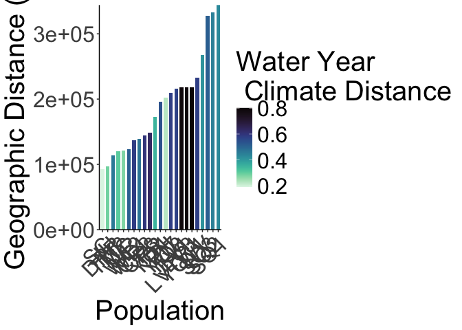

```r
ucd_gowers %>%
  ggplot(aes(x=fct_reorder(pop, Geographic_Dist), y=Geographic_Dist, fill=Wtr_Year_GD_Recent)) +
  geom_col(width = 0.7,position = position_dodge(0.75)) +
  labs(y="Geographic Distance (m)", x="Population", fill="Water Year \n Climate Distance") +
  theme_classic() +
  scale_fill_viridis(option="mako", direction = -1) +
  scale_y_continuous(expand = c(0, 0)) +
  theme(text=element_text(size=30), axis.text.x = element_text(angle = 45,  hjust = 1))
```

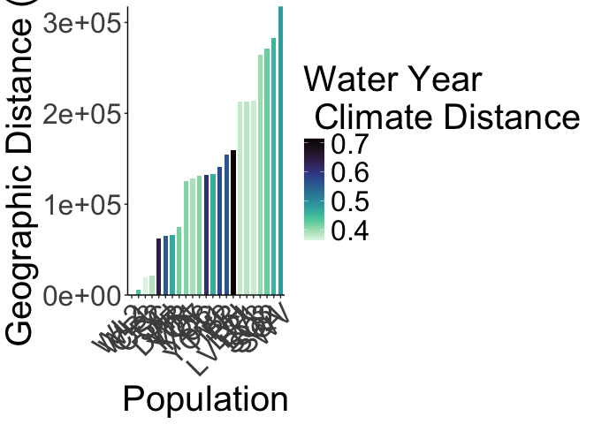

```r
##ggsave("../output/UCD_GeoDist.png", width = 12, height = 8, units = "in")

wl2_gowers_2023 %>%
  ggplot(aes(x=fct_reorder(pop, Geographic_Dist), y=Geographic_Dist, fill=Wtr_Year_GD_Recent)) +
  geom_col(width = 0.7,position = position_dodge(0.75)) +
  labs(y="Geographic Distance (m)", x="Population", fill="Water Year \n Climate Distance") +
  theme_classic() +
  scale_fill_viridis(option="mako", direction = -1) +
  scale_y_continuous(expand = c(0, 0)) +
  theme(text=element_text(size=30), axis.text.x = element_text(angle = 45,  hjust = 1))
```

```r
##ggsave("../output/WL2_GeoDist.png", width = 12, height = 8, units = "in")
```